# **PART = 1**

# First of all, Lets import all the important library

```python
import pandas as pd
import os
import keras
import matplotlib.pyplot  as plt
import numpy as np
import tensorflow as tf
import pickle
from tensorflow.keras.applications.mobilenet import preprocess_input
from zipfile import ZipFile
from sklearn.decomposition import PCA
%tensorflow_version 2.x
import tensorflow
tensorflow.__version__
from matplotlib import pyplot
from tensorflow.keras.losses import binary_crossentropy
from tensorflow.keras.backend import log, epsilon
from tensorflow.keras.applications.mobilenet import MobileNet
from tensorflow.keras.layers import Concatenate, UpSampling2D, Conv2D, Reshape
from tensorflow.keras.models import Model
import tensorflow as tf
from tensorflow.keras.callbacks import ModelCheckpoint, EarlyStopping, ReduceLROnPlateau
import cv2
from tensorflow.keras.models import Sequential
from tensorflow.keras.layers import ZeroPadding2D, Convolution2D, MaxPooling2D, Dropout, Flatten, Activation
from sklearn.preprocessing import LabelEncoder
from tensorflow.keras.models import Model
from sklearn.preprocessing import StandardScaler
from sklearn.svm import SVC
from sklearn.metrics import precision_recall_curve,accuracy_score,f1_score,precision_score,recall_score
```

Now, Lets mount the drive

```python
from google.colab import drive
drive.mount('/content/drive')
```

```python
import os
print(os.listdir("../content"))
```

```
['.config', 'model-2.37.h5', 'model-2.17.h5', 'model-2.36.h5', 'model-2.01.h5', 'model-2.10.h5', 'model-2.31.h5', 'model-0.96.h5', 'model-0.95.h5', 'model-1.96.h5', 'model-1.97.h5', 'model-1.32.h5', 'model-2.46.h5', 'model-2.14.h5', 'model-2.45.h5', 'model-1.00.h5', 'model-2.24.h5', 'model-2.05.h5',…
```

# Now Lets load the dataset

```python
df = np.load('/content/drive/MyDrive/AIML Program/Project/CV 2 - Project/Part 1- Train data - images.npy', allow_pickle = True)
```

Shape of the dataset

```python
df.shape
```

```
(409, 2)
```

# Now, Lets load the test image as well

```python
test_data = cv2.imread('/content/drive/MyDrive/AIML Program/Project/CV 2 - Project/Part 1Test Data - Prediction Image.jpeg')
```

Shape of the test dataset

```python
test_data.shape
```

```
(500, 500, 3)
```

# Now, lets segregate the images and mask from the dataset

```python
images = df[:,0]
mask = df[:,1]
```

Again check the shape of it

```python
print(images.shape)
```

```
(409,)
```

```python
print(mask.shape)
```

```
(409,)
```

# Visualization

**Lets visualize the image so that we'll have some understanding about these images**

[figure not shown]

```python
plt.imshow(images[200])
```

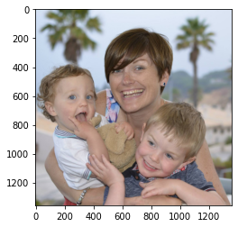

```python
plt.imshow(images[400])
```

[figure not shown]

```python
plt.imshow(images[350])
```

[figure not shown]

```python
plt.imshow(images[280])
```

Lets check the shape of any random image

```python
print(images[400].shape)
```

```
(1357, 1357, 3)
```

```python
mask[400]
```

```
[{'imageHeight': 1357,
  'imageWidth': 1357,
  'label': ['Face'],
  'notes': '',
  'points': [{'x': 0.35969664138678226, 'y': 0.23835319609967498},
   {'x': 0.600216684723727, 'y': 0.4788732394366197}]},
 {'imageHeight': 1357,
  'imageWidth': 1357,
  'label': ['Face'],
  'notes': '',
  'points': [{'x': 0.11700975081256772, 'y': 0.38894907908992415},
   {'x': 0.3131094257854821, 'y': 0.5969664138678223}]},
 {'imageHeight': 1357,
  'imageWidth': 1357,
  'label': ['Face'],
  'notes': '',
  'points': [{'x': 0.5319609967497292, 'y': 0.6164680390032503},
   {'x': 0.7313109425785482, 'y': 0.8548212351029253}]}]
```

```python
display(mask[400])
```

```
[{'imageHeight': 1357,
  'imageWidth': 1357,
  'label': ['Face'],
  'notes': '',
  'points': [{'x': 0.35969664138678226, 'y': 0.23835319609967498},
   {'x': 0.600216684723727, 'y': 0.4788732394366197}]},
 {'imageHeight': 1357,
  'imageWidth': 1357,
  'label': ['Face'],
  'notes': '',
  'points': [{'x': 0.11700975081256772, 'y': 0.38894907908992415},
   {'x': 0.3131094257854821, 'y': 0.5969664138678223}]},
 {'imageHeight': 1357,
  'imageWidth': 1357,
  'label': ['Face'],
  'notes': '',
  'points': [{'x': 0.5319609967497292, 'y': 0.6164680390032503},
   {'x': 0.7313109425785482, 'y': 0.8548212351029253}]}]
```

Now lets define some standard pattern for images height and width

```python
image_width = 224
image_height = 224
alpha = 1
```

Now train the dataset

```python
masks = np.zeros((int(df.shape[0]), image_height, image_width))
X_train = np.zeros((int(df.shape[0]), image_height, image_width, 3))
for index in range(df.shape[0]):
    img = df[index][0]
    img = cv2.resize(img, dsize=(image_height, image_width), interpolation=cv2.INTER_CUBIC)
    try:
      img = img[:, :, :3]
    except:
      continue
    X_train[index] = preprocess_input(np.array(img, dtype=np.float32))
    for i in df[index][1]:
        x1 = int(i["points"][0]['x'] * image_width)
        x2 = int(i["points"][1]['x'] * image_width)
        y1 = int(i["points"][0]['y'] * image_height)
        y2 = int(i["points"][1]['y'] * image_height)
        masks[index][y1:y2, x1:x2] = 1
```

Lets, check the shape of train dataset

```python
X_train.shape
```

```
(409, 224, 224, 3)
```

shape of the masks

```python
masks.shape
```

```
(409, 224, 224)
```

# Lets define some random number for example n=15 to see the train dataset

```python
n = 15
print(X_train[n])
```

[output not shown]

# Again, Lets visualize the data available in x_train dataset

```
Clipping input data to the valid range for imshow with RGB data ([0..1] for floats or [0..255] for integers).
```

[figure not shown]

```python
pyplot.imshow(X_train[n])
```

# Similarly for mask

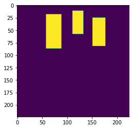

```python
pyplot.imshow(masks[n])
```

# So For we have done all the thing about model, Now its time to create the model. So here we are going to create the model for the dataset

```python
model = MobileNet(input_shape=(224, 224, 3), include_top=False, alpha=1, weights="imagenet")
```

```python
def create_model(trainable=False):
    model = MobileNet(input_shape=(224, 224, 3), include_top=False, alpha=1, weights="imagenet")
    for layer in model.layers:
        layer.trainable = trainable
    block00 = model.layers[0].input
    block01 = model.get_layer("conv_pw_1_relu").output
    block02 = model.get_layer("conv_pw_2_relu").output
    block03 = model.get_layer("conv_pw_3_relu").output
    block05 = model.get_layer("conv_pw_5_relu").output
    block11 = model.get_layer("conv_pw_11_relu").output
    block13 = model.get_layer("conv_pw_13_relu").output
    decoderBlock = Concatenate()([UpSampling2D()(block13), block11])
    decoderBlock = Concatenate()([UpSampling2D()(decoderBlock), block05])
    decoderBlock = Concatenate()([UpSampling2D()(decoderBlock), block03])
    decoderBlock = Concatenate()([UpSampling2D()(decoderBlock), block01])
    decoderBlock = Concatenate()([UpSampling2D()(decoderBlock), block00])
    decoderBlock = Conv2D(1, kernel_size=1, activation="sigmoid")(decoderBlock)
    decoderBlock = Reshape((224, 224))(decoderBlock)
    return Model(inputs=model.input, outputs=decoderBlock)
```

```python
model = create_model()
```

# We have created the model, lets check the summary of it

```python
model.summary()
```

```
Model: "model_2"
__________________________________________________________________________________________________
 Layer (type)                   Output Shape         Param #     Connected to
==================================================================================================
 input_5 (InputLayer)           [(None, 224, 224, 3  0           []
                                )]

 conv1 (Conv2D)                 (None, 112, 112, 32  864         ['input_5[0][0]']
                                )

 conv1_bn (BatchNormalization)  (None, 112, 112, 32  128         ['conv1[0][0]']
                                )

 conv1_relu (ReLU)              (None, 112, 112, 32  0           ['conv1_bn[0][0]']
                                )

 conv_dw_1 (DepthwiseConv2D)    (None, 112, 112, 32  288         ['conv1_relu[0][0]']
                                )

 conv_dw_1_bn (BatchNormalizati  (None, 112, 112, 32  128        ['conv_dw_1[0][0]']
 on)                            )

 conv_dw_1_relu (ReLU)          (None, 112, 112, 32  0           ['conv_dw_1_bn[0][0]']
                                )

 conv_pw_1 (Conv2D)             (None, 112, 112, 64  2048        ['conv_dw_1_relu[0][0]']
                                )

 conv_pw_1_bn (BatchNormalizati  (None, 112, 112, 64  256        ['conv_pw_1[0][0]']
 on)                            )

 conv_pw_1_relu (ReLU)          (None, 112, 112, 64  0           ['conv_pw_1_bn[0][0]']
                                )

 conv_pad_2 (ZeroPadding2D)     (None, 113, 113, 64  0           ['conv_pw_1_relu[0][0]']
                                )

 conv_dw_2 (DepthwiseConv2D)    (None, 56, 56, 64)   576         ['conv_pad_2[0][0]']

 conv_dw_2_bn (BatchNormalizati  (None, 56, 56, 64)  256         ['conv_dw_2[0][0]']
```

[output cut: 195 more lines]

```
 up_sampling2d_14 (UpSampling2D  (None, 224, 224, 19  0          ['concatenate_13[0][0]']
 )                              84)

 concatenate_14 (Concatenate)   (None, 224, 224, 19  0           ['up_sampling2d_14[0][0]',
                                87)                               'input_5[0][0]']

 conv2d_2 (Conv2D)              (None, 224, 224, 1)  1988        ['concatenate_14[0][0]']

 reshape_2 (Reshape)            (None, 224, 224)     0           ['conv2d_2[0][0]']

==================================================================================================
Total params: 3,230,852
Trainable params: 1,988
Non-trainable params: 3,228,864
__________________________________________________________________________________________________
```

# So for we have defined the model also checked the summary of that. our UNET is ready, lets start Defining Dice Coefficient

```python
def dice_coefficient(y_true, y_pred):
    numerator = 2 * tf.reduce_sum(y_true * y_pred)
    denominator = tf.reduce_sum(y_true + y_pred)
    return numerator / (denominator + tf.keras.backend.epsilon())
```

Also lets define the loss as well

```python
def loss(y_true, y_pred):
    return binary_crossentropy(y_true, y_pred) - log(dice_coefficient(y_true, y_pred) + epsilon())
```

```python
model = create_model(False)
model.summary()
```

```
Model: "model_3"
__________________________________________________________________________________________________
 Layer (type)                   Output Shape         Param #     Connected to
==================================================================================================
 input_6 (InputLayer)           [(None, 224, 224, 3  0           []
                                )]

 conv1 (Conv2D)                 (None, 112, 112, 32  864         ['input_6[0][0]']
                                )

 conv1_bn (BatchNormalization)  (None, 112, 112, 32  128         ['conv1[0][0]']
                                )

 conv1_relu (ReLU)              (None, 112, 112, 32  0           ['conv1_bn[0][0]']
                                )

 conv_dw_1 (DepthwiseConv2D)    (None, 112, 112, 32  288         ['conv1_relu[0][0]']
                                )

 conv_dw_1_bn (BatchNormalizati  (None, 112, 112, 32  128        ['conv_dw_1[0][0]']
 on)                            )

 conv_dw_1_relu (ReLU)          (None, 112, 112, 32  0           ['conv_dw_1_bn[0][0]']
                                )

 conv_pw_1 (Conv2D)             (None, 112, 112, 64  2048        ['conv_dw_1_relu[0][0]']
                                )

 conv_pw_1_bn (BatchNormalizati  (None, 112, 112, 64  256        ['conv_pw_1[0][0]']
 on)                            )

 conv_pw_1_relu (ReLU)          (None, 112, 112, 64  0           ['conv_pw_1_bn[0][0]']
                                )

 conv_pad_2 (ZeroPadding2D)     (None, 113, 113, 64  0           ['conv_pw_1_relu[0][0]']
                                )

 conv_dw_2 (DepthwiseConv2D)    (None, 56, 56, 64)   576         ['conv_pad_2[0][0]']

 conv_dw_2_bn (BatchNormalizati  (None, 56, 56, 64)  256         ['conv_dw_2[0][0]']
```

[output cut: 195 more lines]

```
 up_sampling2d_19 (UpSampling2D  (None, 224, 224, 19  0          ['concatenate_18[0][0]']
 )                              84)

 concatenate_19 (Concatenate)   (None, 224, 224, 19  0           ['up_sampling2d_19[0][0]',
                                87)                               'input_6[0][0]']

 conv2d_3 (Conv2D)              (None, 224, 224, 1)  1988        ['concatenate_19[0][0]']

 reshape_3 (Reshape)            (None, 224, 224)     0           ['conv2d_3[0][0]']

==================================================================================================
Total params: 3,230,852
Trainable params: 1,988
Non-trainable params: 3,228,864
__________________________________________________________________________________________________
```

Lets create optimizer for the model

```python
optimizer = tf.keras.optimizers.Adam(lr=1e-4, beta_1=0.9, beta_2=0.999, epsilon=None, decay=0.0, amsgrad=False)
```

lets, Compile the model

```python
model.compile(loss=loss, optimizer = optimizer, metrics=[dice_coefficient])
```

```python
limit = ModelCheckpoint("model-{loss:.2f}.h5", monitor="loss", verbose=1, save_best_only=True,save_weights_only=True, mode="min", save_freq=1)
```

```python
pause = EarlyStopping(monitor="loss", patience=5, mode="min")
```

```python
lr_ = ReduceLROnPlateau(monitor="loss", factor=0.2, patience=1, min_lr=1e-6, verbose=1, mode="min")
```